# Reproducible Research Course Project 1

jin.jiangli@mayo.edu

12/5/2019

# Background

This R Markdown document was created for the assignment of “Reproducible Research” course by [coursera](https://www.coursera.org/)

More information about the assignment, see README.md

# Assignment

The data for this assignment can be downloaded from the course web site:

- Dataset: [Activity monitoring data](https://d396qusza40orc.cloudfront.net/repdata%2Fdata%2Factivity.zip)

After download, unzip the downloaded file to your working directory, make sure the unzipped file “activity.csv” existed

## Loading and preprocessing the data:

```r
library(plyr)
library(lattice)

walk_data <- read.csv("activity.csv")
```

## What is mean total number of steps taken per day?

1. Make a histogram of the total number of steps taken each day

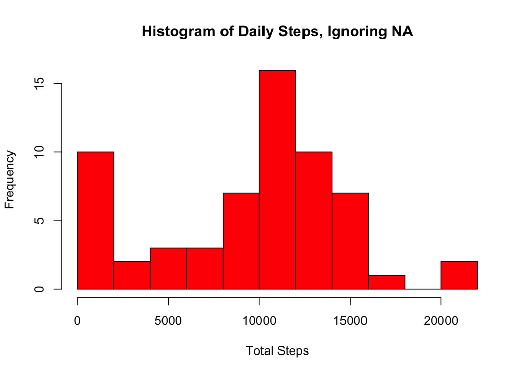

```r
day_total_steps <- ddply(walk_data, .(date), summarise, totalSteps = sum(steps, na.rm=TRUE))
hist(day_total_steps$totalSteps,
     breaks = 10,
     xlab = "Total Steps",
     main = "Histogram of Daily Steps, Ignoring NA",
     col = "red"
)
```

2. Calculate and report the mean and median total number of steps taken per day

```r
day_step_mean <- mean(day_total_steps$totalSteps, na.rm = TRUE)
day_step_median <- median(day_total_steps$totalSteps, na.rm = TRUE)
```

mean total number of steps taken per day: 9354.23  
median total number of steps taken per day: 10395

## What is the average daily activity pattern?

1. Make a time series plot (i.e. type = “l”) of the 5-minute interval (x-axis) and the average number of steps taken, averaged across all days (y-axis)

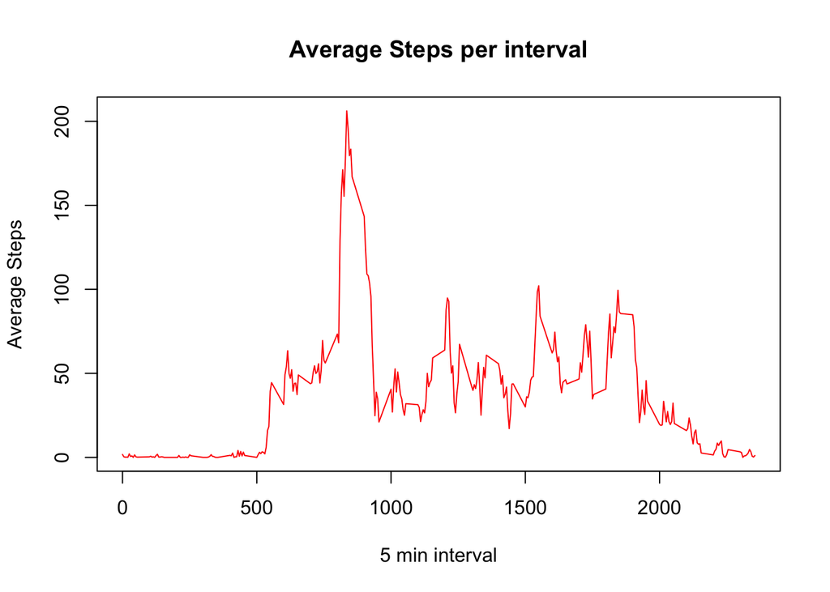

```r
mean_interval <- ddply(walk_data, .(interval), summarise,  AverageSteps = mean(steps, na.rm=TRUE))
plot(mean_interval$interval,
     mean_interval$AverageSteps,
     type = "l",
     xlab = "5 min interval",
     ylab = "Average Steps",
     main = "Average Steps per interval",
     col="red"
)
```

2. Which 5-minute interval, on average across all the days in the dataset, contains the maximum number of steps?

```r
max_steps_mean_index <- which.max(mean_interval$AverageSteps)
```

No 104 5-minute interval cantains the max number of steps.

## Imputing missing values

```r
sum_na <- sum(is.na(walk_data))
```

2. Create a new dataset that is equal to the original dataset but with the missing data filled with the mean for that 5-minute interval

```r
walk_data_new <- merge(walk_data, mean_interval, by="interval", sort=TRUE)
index <- is.na(walk_data_new$steps)
walk_data_new$steps[index] <- walk_data_new$AverageSteps[index]
```

3. Make a histogram of the total number of steps taken each day with new dataframe.

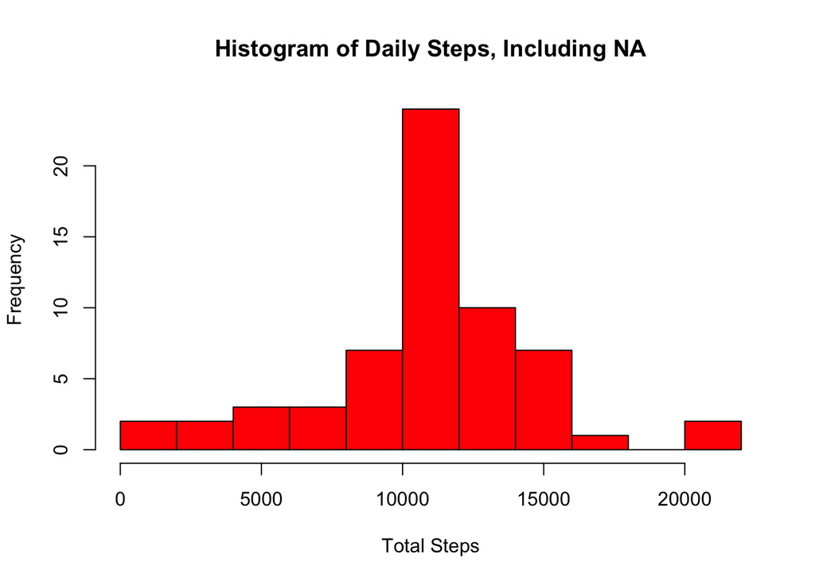

```r
day_total_steps2 <- ddply(walk_data_new, .(date), summarise, totalSteps=sum(steps, na.rm = TRUE)) #Group on date, total steps
hist(day_total_steps2$totalSteps,
     breaks=10,
     main = "Histogram of Daily Steps, Including NA",
     xlab="Total Steps",
     col = "red"
)
```

```r
day_step_mean2 <- mean(day_total_steps2$totalSteps)
day_step_median2 <- median(day_total_steps2$totalSteps)
```

new mean total number of steps taken per day: 10766.19  
new median total number of steps taken per day: 10766.19

## Are there differences in activity patterns between weekdays and weekends?

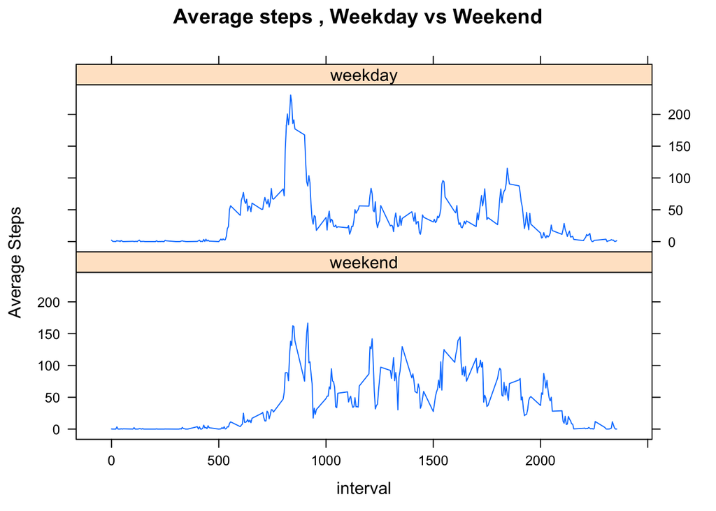

```r
walk_data_new$date <- as.Date(walk_data_new$date)
day_new <- factor(weekdays(walk_data_new$date) %in% c("Saturday", "Sunday"), level=c(TRUE, FALSE), labels=c("weekend", "weekday"))
tmp1 <- mutate(walk_data_new, day = day_new)
tmp2 <- ddply(tmp1, .(interval, day), summarise, averageSteps = mean(steps))
xyplot(averageSteps ~ interval | day,
       data = tmp2,
       type = "l",
       layout = c(1, 2),
       ylab = "Average Steps",
       main = "Average steps , Weekday vs Weekend")
```

The trends of the two figures are similar,average numbers of steps taken per 5-minutes interval across all weekend days are higher on average than that across all weekday days seemly, but maxium value was during weekday.